# Visualizing Growth Using World Bank Development Indicators

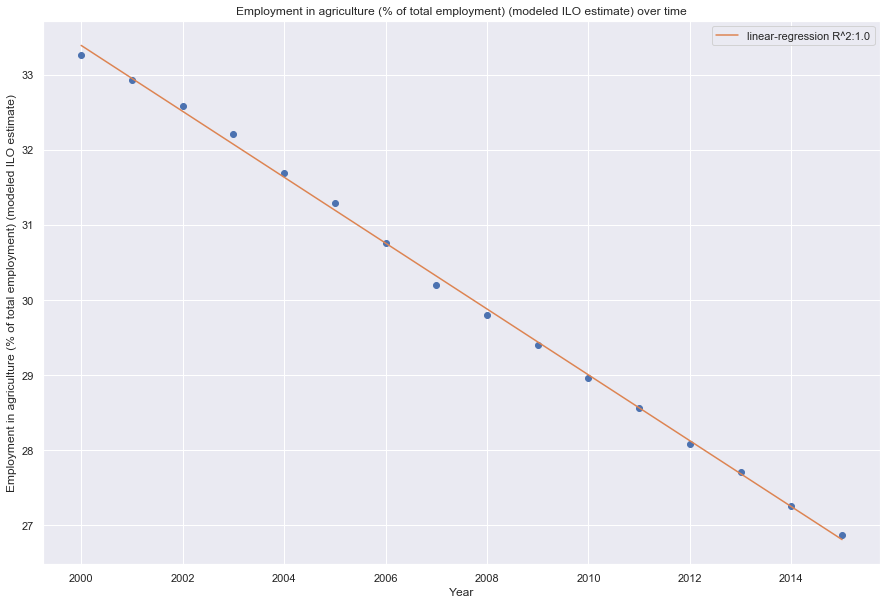

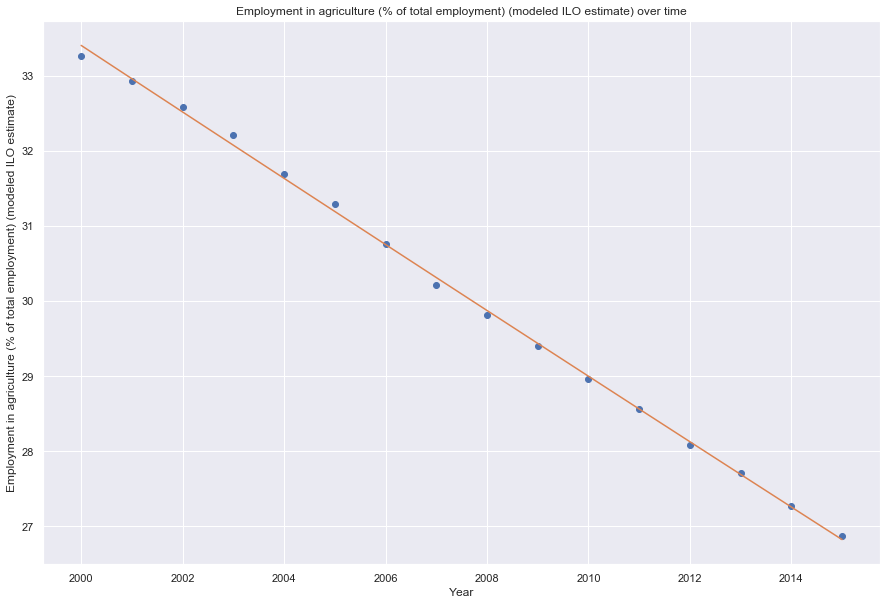

```
0.9987835752393046
```

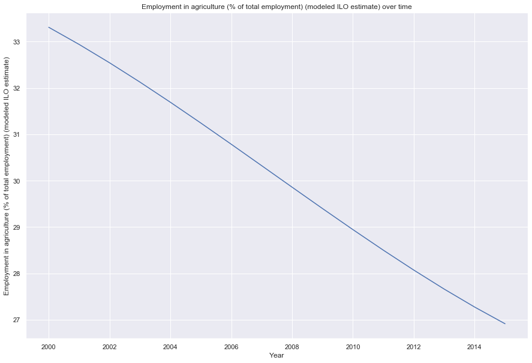

```
0.9994047894666219
```

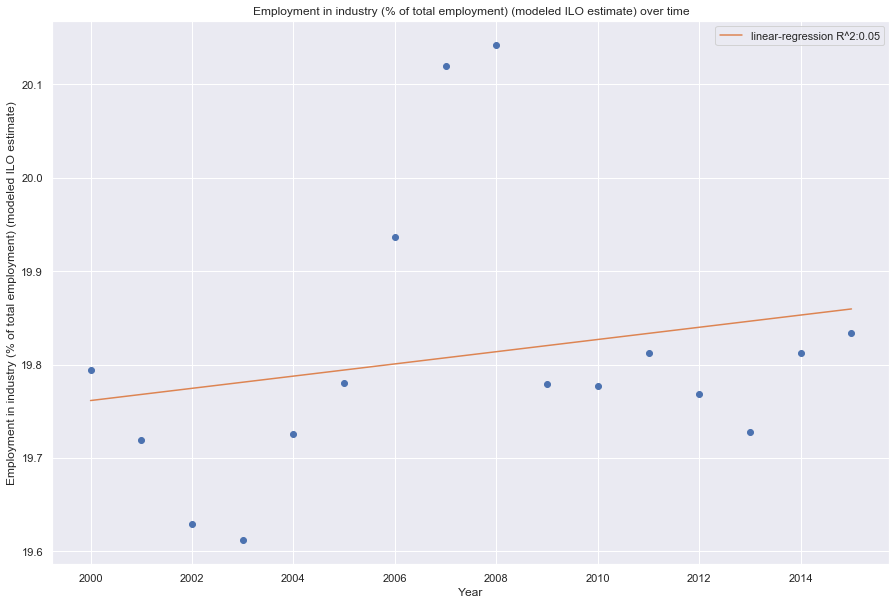

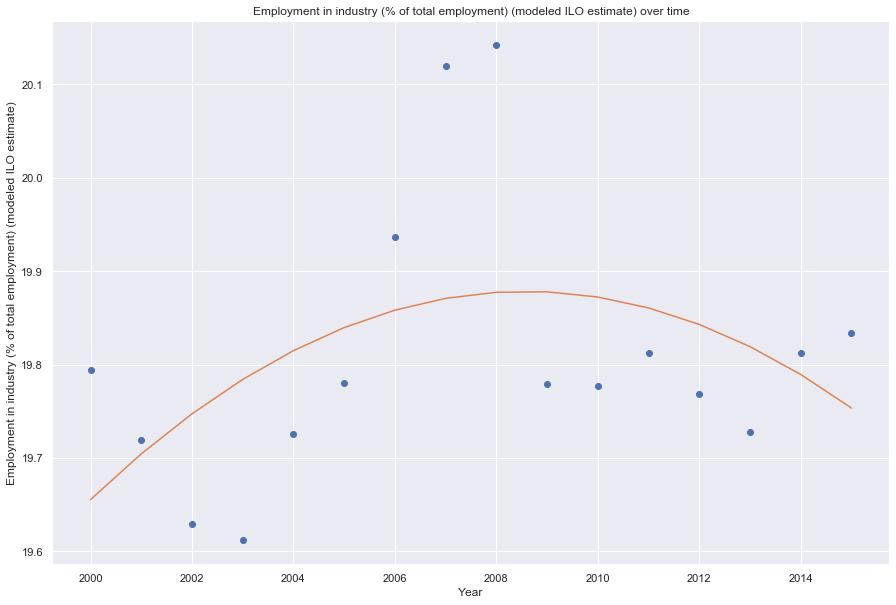

```
0.2084906604232991
```

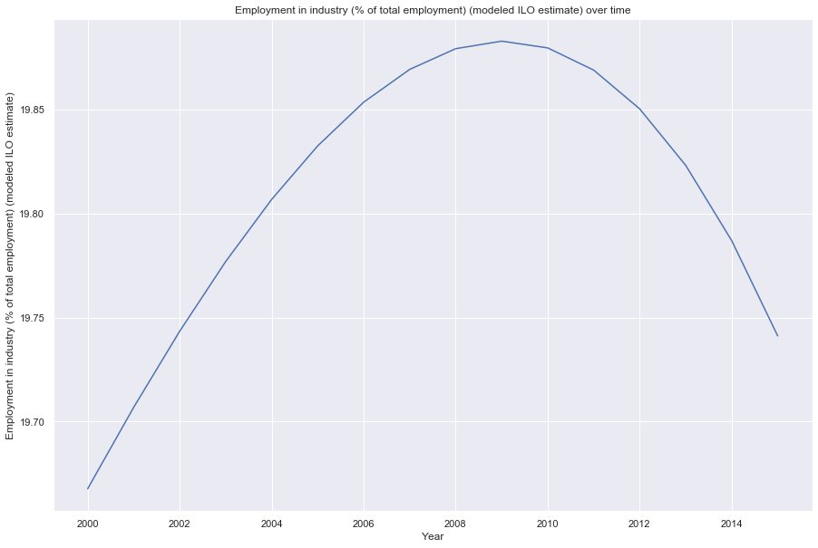

```
0.2108347351276589
```

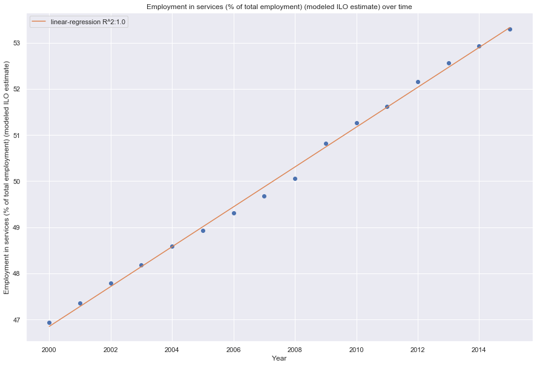

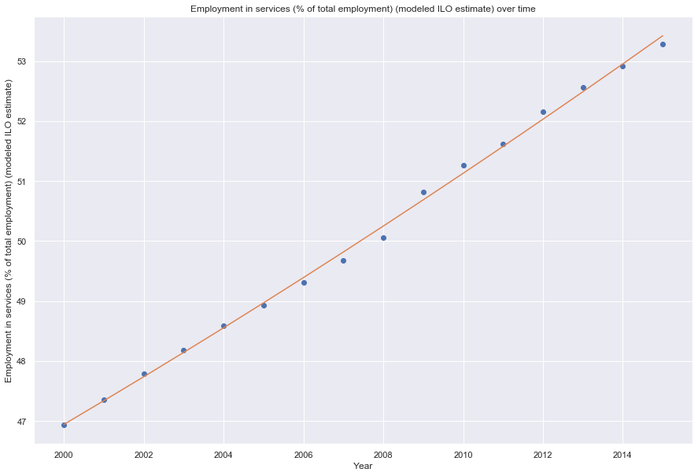

```
0.9976542268530653
```

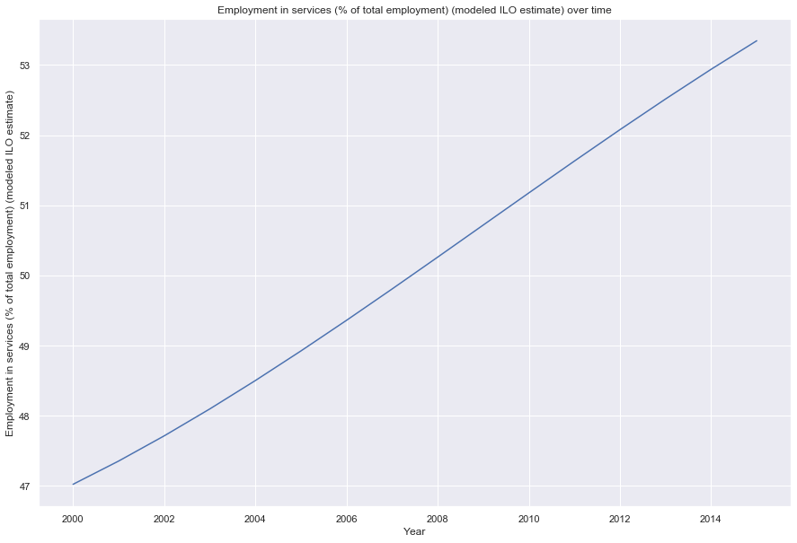

```
0.9981311430679118
```

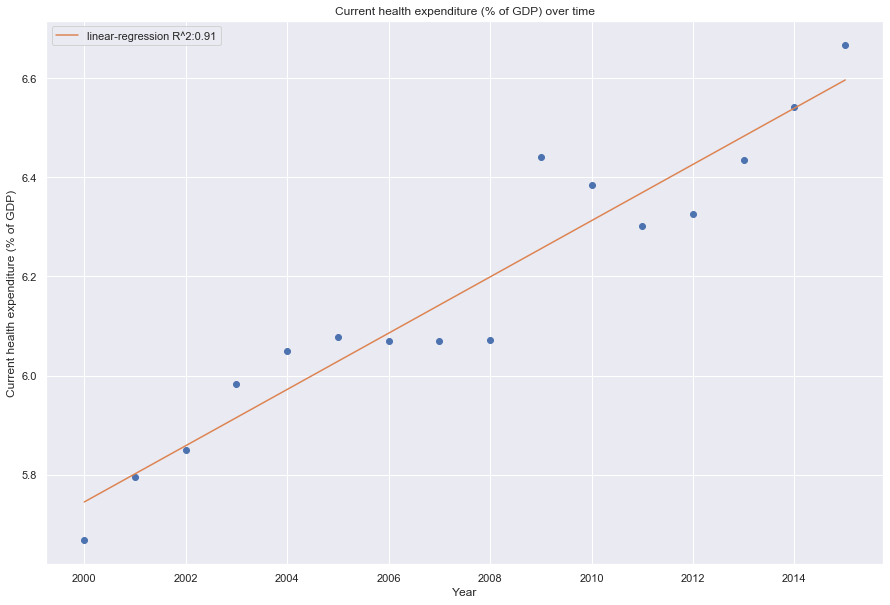

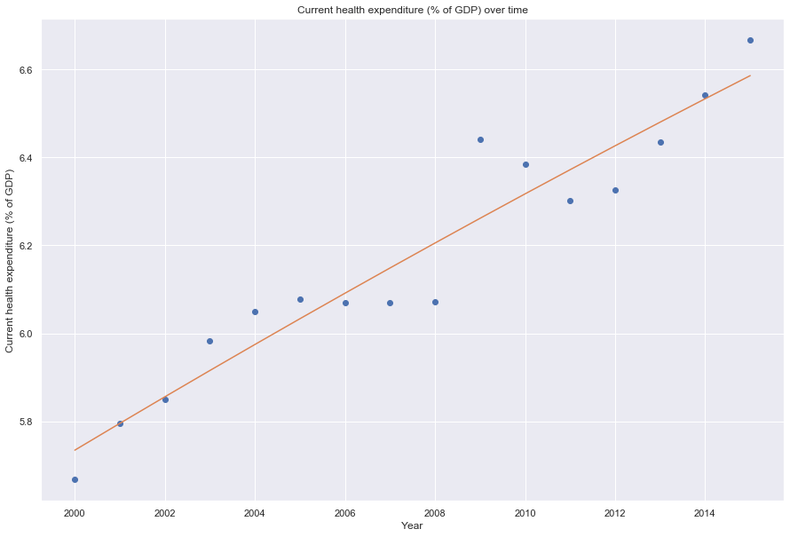

```
0.915137645330299
```

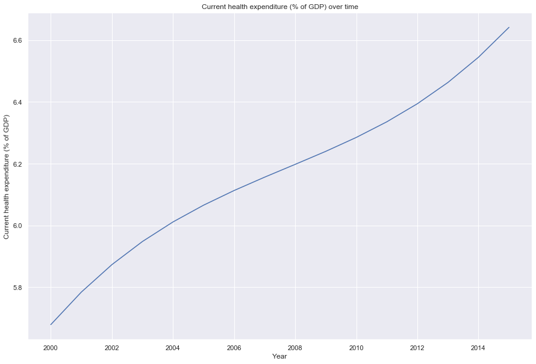

```
0.9275785732289996
```

[12 more figures not shown]

```
0.9536391551903989
```

```python
plot_GDP_predictors("Employment in agriculture (% of total employment) (modeled ILO estimate)",1,linearmiscData)
plot_GDP_predictors("Employment in industry (% of total employment) (modeled ILO estimate)",2,linearmiscData)
plot_GDP_predictors("Employment in services (% of total employment) (modeled ILO estimate)",3,linearmiscData)
plot_GDP_predictors("Current health expenditure (% of GDP)",4,linearmiscData)
plot_GDP_predictors("Fertility rate, total (births per woman)",5,linearmiscData)
plot_GDP_predictors("Government expenditure on education, total (% of GDP)",6,linearmiscData)
plot_GDP_predictors("Prevalence of undernourishment (% of population)",7,linearmiscData)
plot_GDP_predictors("Adjusted net enrollment rate, primary (% of primary school age children)",8,linearmiscData)
```

Results here show that employment in agriculture trends downwards over time, employment in industry over time cannot be conclusive, employment in services trends upwards over time, current health expenditure trends upwards over time, fertility rate trends downwards over time, government expenditure in education over time is not conclusive, prevalence of undernourishment trends downwards over time, and adjusted net enrollment rate trends upwards over time.

## Insight and Policy Decision

### 5.0 Summary

For this project, we wanted to analyze the effect that various data points have on the economies of different countries. In order to do this we first collected data from the World Bank data set that included variables that are known to calculate GDP as well as some miscellaneous variables that we thought could be used to visualize GDP growth. We then broke this data into two different data frames, with one representing the variables used to calculate GDP and the other representing the variables we thought could be used to visualize GDP. The data frames were then transformed, so that the columns consisted of variables, with each row representing an instance of a country and a year. We then performed analyses on the two data frames by plotting the correlation between the different variables to GDP per capita. Linear regression was then used for in-depth analysis as we tried to visualize the growth of GDP in countries over time.

### 5.1 Insight

With this data we concluded some aspects of economics which we were already aware of and found out some information that suprised us. For example, there was very little correlation between GDP per capita and the percentage of GDP spent on education. But our predicitons about lower birth rates in more developed countries shown to be supported by the data we plotted. Visualizing economics through data science is an extremely important field, and the large amount of information organizations such as the World Bank and the IMF give solidifies that. With this information, economists can attempt to form more accurate models and predictions that could impact billions of people. Hopefully, this tutorial has allowed you to get a glimpse on the potential visualizing databanks such as these can have on our perceptions and decisions regarding important economic topics.